# Chatbot Documentation

## Chatbot Functionality

The financial chatbot was developed using Python, Flask, HTML, and CSS.  
It responds to predefined financial queries using analyzed SEC 10-K financial data of Microsoft, Tesla, and Apple from 2023–2025.

The chatbot uses simple conditional logic (`if-elif`) to identify user queries and provide accurate financial responses.

## Predefined Queries Supported

- What is the total revenue of Apple in 2025?
- How has Microsoft net income changed from 2023 to 2025?
- What is Tesla operating cash flow in 2025?
- Which company demonstrated the strongest financial performance overall?
- How did Microsoft perform in terms of financial growth?
- Which company has the highest revenue?
- Which company showed the best growth?

Users can also type:

- `help` → to view all available queries
- `exit` → to stop the chatbot

## Test Results

The chatbot was tested with all predefined queries.

### Sample Outputs

- Apple reported the highest revenue in 2025.
- Microsoft showed strong financial growth and increasing profitability.
- Tesla experienced declining net income despite stable revenue performance.

The chatbot successfully returned accurate responses based on the uploaded financial dataset.

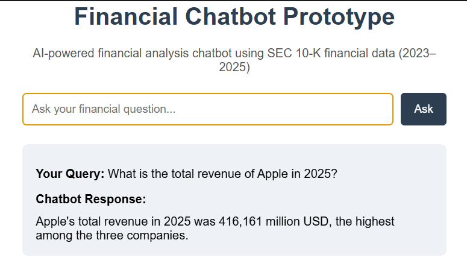

## Limitations

- The chatbot supports only predefined financial queries.
- It does not support real-time AI conversations or NLP-based understanding.
- Responses are limited to the analyzed SEC financial data from 2023–2025.

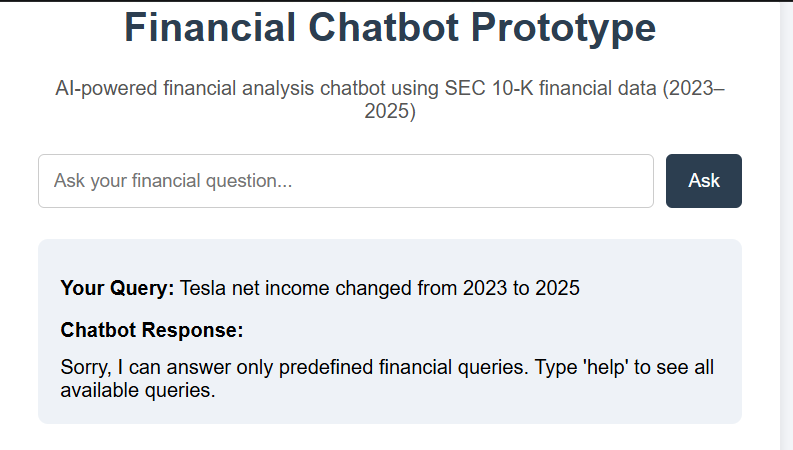

# Execution Steps

1. Open file in VS Code
2. Open new Terminal
3. Run the chatbot using:
   - python app.py
4. Open the link shown in the terminal(example: http://127.0.0.1:5000).
5. Enter predefined financial queries in the chatbot

## Conclusion

This chatbot prototype demonstrates the basic implementation of an AI-powered financial assistant using Python and financial data analytics.